# Analysis of a Survey (Attitudes towards Cheese) with Multiple Correspondence Analysis

Hervé Abdi, Dominique Valentin, Maud Lelièvre, & Sylvie Chollet

2020-08-22

# 1 Prelude

If you want to make sure that you have a clean start, you can execute the following commands:

```r
rm(list = ls())
graphics.off()
```

Or, better (see below, preamble), you can use an `Rproject` for this project.

# 2 Preambule

Make sure that you start this analysis as a new `Rproject` so that the default directory will be correctly set.

Before we start the analysis, we need to have our standard packages installed (some from `Github`) and the corresponding libraries loaded:

- `Distatis` (from *Github*)
- `ExPosition`
- `InPosition`
- `PTCA4CTA` (from *Github*)
- `R4SPISE2018`(from *Github*)
- `dplyr` (to recode the data)
- `car` (to recode the data)
- `grid`, `gridExtra`, and `gTable` (to save tables as graphics)
- `stringi` (to recode strings).

and all their extensions:

```r
# Decomment all/some these lines if the packages are not installed
# devtools::install_github('HerveAbdi/PTCA4CATA')
# devtools::install_github('HerveAbdi/DistatisR')
# devtools::install_github('HerveAbdi/R4SPISE2018') # of course!
#  install.packages(prettyGraphs)
#  install.packages('Matrix')
#  install.packages('dplyr')
#  install.packages('gridExtra')
#  install.packages('grid')
#  install.packages('gtable')
#  install.packages('stringi')
#  load the libraries that we will need
suppressMessages(library(Matrix))
suppressMessages(library(DistatisR))
suppressMessages(library(PTCA4CATA))
suppressMessages(library(prettyGraphs))
suppressMessages(library(ExPosition))
suppressMessages(library(dplyr))
suppressMessages(library(gridExtra)) # to save a table as a graph
suppressMessages(library(grid))      # that will be saved in the
suppressMessages(library(gtable))    # powerpoint with the figures
```

# 3 Introduction

The data set can be found from the package `R4SPISE2018.` The data are stored in an excel file called `miniCheeseSurvey4MCA.xlsx` whose location can be found and stored in the variable `path2file` using the `R` function `system.functionfile()` as shown in the following command:

```r
path2file <- system.file("extdata",
       "miniCheeseSurvey4MCA.xlsx", package = "R4SPISE2018")
```

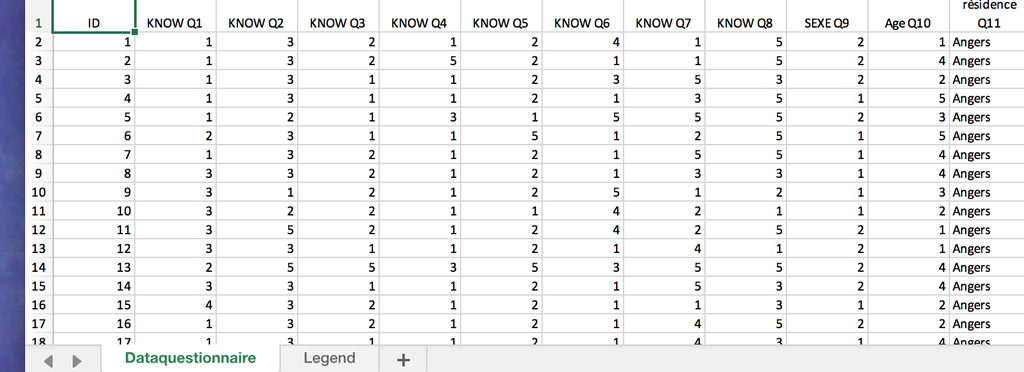

The Data Excel File

Now the variable `path2file` contains the name (and location) of the excel data file. If you open this excel file, it will look like the figure above. The sorting data are stored in the sheet labeled `Data.` The first column gives the ID of the respondents and each column represents a question asked to the respondents. At the intersection of a row and a column we have the response of a respondent (row) to a question (column).

When you record your own data, make sure that you follow the same format, this way the script described in this vignette will apply to your own analysis with minimal change.

We will first compute the results of the analysis, then create the graphics, and finally save everything into a powerpoint.

# 4 Run the statistical analysis

## 4.1 Read the data

Recall that, the excel file name and location (i.e., path) are stored in the variable `path2file`. To read the data we will use the function `DistatisR::read.df.excel()` (based upon the function `readxl::read_excel()`).

```r
rawData <- read.df.excel(path = path2file, sheet = 'Data')$df.data
```

The data are now read and stored in the data frame called `rawData`.

### 4.1.1 To save the file

To save the data file (under the—not very—original name of `myDataFile` or maybe a more informative name) in a directory (say `Downloads`). use the following command

```r
saveFile <- file.copy(from = path2file, to = '~/Downloads/myDataFile.xlsx')
```

## 4.2 Analysis plan

In this example we will analyze the answers to two sets of questions.

The first set evaluates the knowledge of the respondent: and it comprises the questions `Q01_Know1` to `Q08_Know8` (or 1 to 8); these questions have 5 different options one correct and 4 incorrect options. Here we have decided to code these questions with only two values: correct or incorrect.

the second set comprises the questions `Q15_C01` to `Q38_C24` (or 32 to 55); these questions evaluate the behaviors, opinions, or attitudes of the respondents toward cheese that are either farm-made or industrial. These questions are answered with a 4 point Likert scale (from 1 meaning “I totally agree” to 4 meaning “I totally disagree”)

In addition we have some information about the respondents: Sex `(Q09_Sex)`, Age `(Q10_Age)`, the city where they live `(Q11_City)`.

## 4.3 Selection and recoding

In MCA, before proceeding to analysis *per se*, all variables need to be nominal variables with the constraint that the different levels of a variable are roughly balanced. When a variable is already nominal, the process is straightforward but some levels may need to be fused to have the levels roughly balanced. For ordinal or quantitative data the procedure is to “bin” the data so that the bins are roughly balanced

## 4.4 From one dataframe to the other

From the dataframe `rawData` we know create the new dataframe `cleanData`. It will have the same rows but the columns are obtained by recoding the columns of `rawData.`

The first step is to create the new data frame with only the variables we want to use; we also re-order the variables to have the respondent variables (i.e., Sex, Age, city) first. This is done with this line of code

```r
temp.df <- dplyr::select(rawData, Q09_Sex:Q11_City, Q01_Know1:Q08_Know8,
                   Q15_C01:Q38_C24)
```

### 4.4.1 Participant description

We use `car::recode` to recode the variable `sex` from 1/2 to m/f

```r
# We recode sex as m/f
sex  =  car::recode(temp.df[,'Q09_Sex'], " 1 = 'm';2 = 'f'")
```

### 4.4.2 Knowledge

The questions `Q01_Know1` to `Q08_Know8` are knowledge questions their sum could go from 0 to 8:

```r
# correct responses
correct.Know = c(3,3,1,2,1,1,1,3)
# where are the knowledge questions
knowQuestions = (substr( colnames(temp.df),5,8)   == 'Know')
# Get the number of correct amswers
correct.answers =  rowSums(matrix(correct.Know, nrow = nrow(temp.df),
                   ncol = length(correct.Know), byrow = TRUE) ==
           temp.df[,which(knowQuestions)])
```

But in this sample the sum goes from 1 to 6 with a mode at 4/5 as can be seen from the histogram of the number of correct answers.

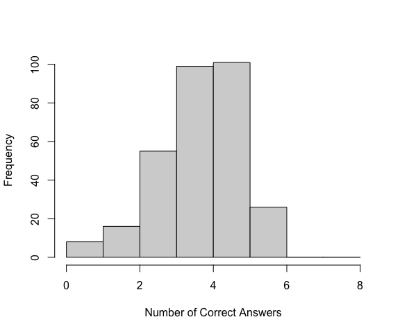

```r
hist(correct.answers, main = '', breaks = 0:8,  xlab = 'Number of Correct Answers')
```

we will concatenate them.and re-evaluate them from 1 to 3

```r
# Make only three categories use recode from package car
know =  car::recode(correct.answers, "0 = 1; 1 = 1; 2 = 1; 3 = 1; 4 = 2; 5 = 3; 6 = 3")
```

We will also recode the variable `Age` into four levels

```r
oriAge <- temp.df$Q10_Age
newAge  <- car::recode(oriAge, "1 = 1; 2 = 1; 3 = 2; 4 = 3; 5 = 4; 6 = 4")
```

### 4.4.3 Attitudes

The first step when analyzing Likert scales is to look at the distribution of the scores. Here we will create a table with the questions as rows and the columns as levels (from 1 to 4).

```r
knitr::kable( t(apply(rawData[,32:55],2,function(x){summary(as.factor(x))})))
```

|  | 1 | 2 | 3 | 4 |
| --- | --- | --- | --- | --- |
| Q15_C01 | 47 | 132 | 108 | 18 |
| Q16_C02 | 26 | 68 | 153 | 58 |
| Q17_C03 | 10 | 81 | 153 | 61 |
| Q18_C04 | 18 | 77 | 116 | 94 |
| Q19_C05 | 85 | 72 | 113 | 35 |
| Q20_C06 | 101 | 149 | 47 | 8 |
| Q21_C07 | 55 | 92 | 126 | 32 |
| Q22_C08 | 64 | 138 | 84 | 19 |
| Q23_C09 | 57 | 78 | 114 | 56 |
| Q24_C10 | 53 | 111 | 97 | 44 |
| Q25_C11 | 64 | 100 | 120 | 21 |
| Q26_C12 | 33 | 102 | 146 | 24 |
| Q27_C13 | 81 | 123 | 82 | 19 |
| Q28_C14 | 108 | 143 | 49 | 5 |
| Q29_C15 | 129 | 129 | 41 | 6 |
| Q30_C16 | 84 | 180 | 36 | 5 |
| Q31_C17 | 44 | 163 | 88 | 10 |
| Q32_C18 | 24 | 115 | 139 | 27 |
| Q33_C19 | 13 | 56 | 153 | 83 |
| Q34_C20 | 7 | 40 | 188 | 70 |
| Q35_C21 | 8 | 38 | 188 | 71 |
| Q36_C22 | 12 | 54 | 193 | 46 |
| Q37_C23 | 25 | 93 | 173 | 14 |
| Q38_C24 | 24 | 96 | 167 | 18 |

This table shows that the levels of the responses are not very balanced, so we decided to binarize the answers and to keep only the subset of questions that can be binarized as {1,2}|{3,4} (other choices would have been acceptable of course). The set that we keep is in the variable `Lick2Keep`

```r
Lick2Keep = c('Q15_C01','Q19_C05','Q21_C07',
               'Q24_C10','Q25_C11','Q32_C18')
```

```r
Lickert <- temp.df[, colnames(temp.df) %in% Lick2Keep]
recl <- function(x){y = car::recode(x, "1 = 1; 2 = 1; 3 = 2; 4 = 2") }
rec.Lickert <- apply(Lickert,2,recl)
```

### 4.4.4 New cleaned data set

We can now put together the new data set

```r
cleanData <- cbind(sex,newAge,rawData$Q11_City,know,rec.Lickert)
colnames(cleanData) <- c('Sex','Age','City','Know',
                          'C01','C05','C07','C10','C11','C18')
# make sure that there is no NA left
cleanData <- cleanData[complete.cases(cleanData),]
```

The dataframe is now ready to be analyzed with multiple correspondence analysis

# 5 Multiple Correspondence Analysis

## 5.1 Complete analysis

Use the function `epMCA` from the package `ExPosition`

```r
resMCA <- epMCA(cleanData, graphs = FALSE)
```

# 6 Subset analysis

Because Dimension 1 mostly separates the inhabitants of Lille from the inhabitants of Angers, we decided to perform a subset analysis and analyze separately the data from each city.

## 6.1 Lille

Create the “Lille” data set by subsetting the whole data set.

```r
 cleanData.Lille = cleanData[cleanData[,'City'] == 'Lille',]
 cleanData.Lille <- cleanData.Lille[, (colnames(cleanData.Lille) != 'City') ]
```

## 6.2 MCA Lille

```r
resMCA.Lille <- epMCA(cleanData.Lille, graphs = FALSE)
```

## 6.3 Angers

Create the “Angers” data set by subsetting the whole data set.

```r
 cleanData.Angers <- cleanData[cleanData[,'City'] == 'Angers',]
 cleanData.Angers <- cleanData.Angers[, (colnames(cleanData.Angers) != 'City') ]
```

# 7 MCA Angers

```r
 resMCA.Angers <- epMCA(cleanData.Angers, graphs = FALSE)
```

# 8 Graphics

Make some graphs.

First, get the colors for the variables

```r
cJ <- resMCA$ExPosition.Data$cj
color4Var <- prettyGraphs::prettyGraphsColorSelection(ncol(cleanData))
```

## 8.1 Variable contributions

```r
# Extract the root names before the "."
varNames <- stringi::stri_extract(rownames(cJ),regex = '[^.]*')
varCtr.tmp <- aggregate(cJ ~ varNames, (cbind(varNames,cJ)),sum)
varCtr <- varCtr.tmp[,-1]
rownames(varCtr)    <- varCtr.tmp[,1]
rownames(color4Var) <- varCtr.tmp[,1]
```

The variable contributions show the variables important for a given dimension.

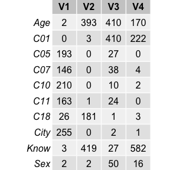

```r
nFact <- min(5, ncol(cJ) - 1)
# knitr::kable(round( varCtr[,1:nFact]*1000 ) )
# save table as a graph
ctrTable <- tableGrob(round(varCtr[,1:nFact]*1000))
h <- grobHeight(ctrTable)
w <- grobWidth(ctrTable)
title <- textGrob("Variable Contributions",
                  y = unit(0.5,"npc") + 1.2*h,
                  vjust = 0,
                  gp = gpar(fontsize=15))
TableWithTitle <- gTree(children = gList(ctrTable, title))
grid.draw(TableWithTitle)
```

```r
a00.1.ctrTable  <- recordPlot()
```

To create graphics we will color the labels of a given variable with the same color. First we create the vector storing the colors.

```r
nM   <- nrow(cJ)
nVar <- nrow(color4Var)
col4Labels <- rep("",nM)

for (i in 1:nVar){
  lindex <- varNames %in% rownames(color4Var)[i]
  col4Labels[lindex] <- color4Var[i]
}
```

## 8.2 Scree plot for the MCA

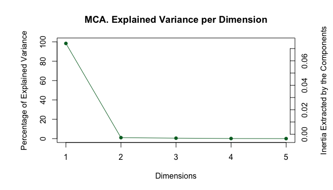

```r
# 5.A. A scree plot for the RV coef. Using standard plot (PTCA4CATA)
scree.mca <- PlotScree(ev = resMCA$ExPosition.Data$eigs,
                   p.ev = NULL, max.ev = NULL, alpha = 0.05,
                   col.ns = "#006D2C", col.sig = "#54278F",
                   title = "MCA. Explained Variance per Dimension",
                   plotKaiser = FALSE,
                   color4Kaiser = "darkorchid4",
                   lwd4Kaiser = 2.5)
```

```r
a1.Scree <- recordPlot() # Save the plot
```

## 8.3 Variable Map

```r
axis1 = 1
axis2 = 2
Fj <- resMCA$ExPosition.Data$fj
# generate the set of maps
BaseMap.Fj <- createFactorMap(X = Fj , # resMCA$ExPosition.Data$fj,
                              axis1 = axis1, axis2 = axis2,
                              constraints = NULL,
                              title = 'MCA. Variables',
                              col.points = col4Labels,
                              display.points = TRUE,
                              pch = 19, cex = 1,
                              display.labels = TRUE,
                              col.labels = col4Labels,
                              text.cex = 2.5, font.face = "bold",
                              font.family = "sans",
                              col.axes = "darkorchid",
                              alpha.axes = 0.2,
                              width.axes = 1.1,
                              col.background = adjustcolor("lavender",
                                                       alpha.f = 0.2),
                              force = 2, segment.size = 0)
# add labels
labels4MCA <- createxyLabels.gen(x_axis = axis1,
                                   y_axis = axis2,
               lambda = resMCA$ExPosition.Data$eigs,
               tau = resMCA$ExPosition.Data$t)
# make the maps
aa.1.BaseMap.Fj <- BaseMap.Fj$zeMap +  labels4MCA
aa.2.BaseMapNoDot.Fj  <- BaseMap.Fj$zeMap_background +
                          BaseMap.Fj$zeMap_text + labels4MCA
```

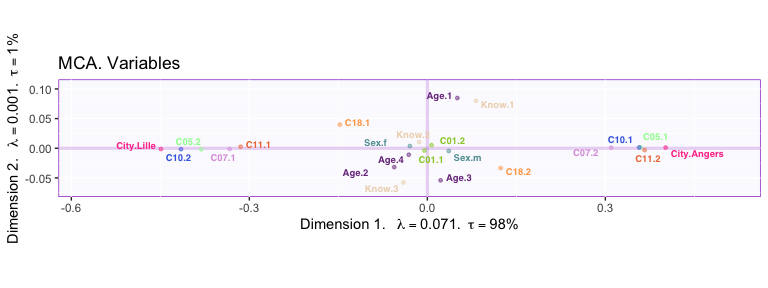

```r
print(aa.1.BaseMap.Fj)
```

## 8.4 Map for the observations

Here we color the observations by `City`, to confirm that this is, indeed, the main source of variation for this data set.

```r
Fi <- resMCA$ExPosition.Data$fi
colCity <- c('darkblue', 'red4')
nI <- nrow(Fi)
col4I.City <- rep("",nI)
for (i in 1:length(colCity) ){
  lindex <- cleanData[,'City'] %in% unique(cleanData[,'City'])[i]
  col4I.City[lindex] <- colCity[i]
}
# generate the set of maps
BaseMap.Fi <- createFactorMap(X = Fi , # resMCA$ExPosition.Data$fj,
                              axis1 = axis1, axis2 = axis2,
                              constraints = NULL,
                              title = 'MCA. Variables',
                              col.points = col4I.City,
                              alpha.points = .2,
                              display.points = TRUE,
                              pch = 19, cex = .8,
                              display.labels = TRUE,
                              col.labels = col4I.City,
                              text.cex = 2.5, font.face = "bold",
                              font.family = "sans",
                              col.axes = "darkorchid",
                              alpha.axes = 0.2,
                              width.axes = 1.1,
                              col.background = adjustcolor("lavender",
                                                       alpha.f = 0.2),
                              force = 2, segment.size = 0)
# make the maps
aa.5.BaseMapNoLabels.Fi  <- BaseMap.Fi$zeMap_background +
                          BaseMap.Fi$zeMap_dots + labels4MCA
```

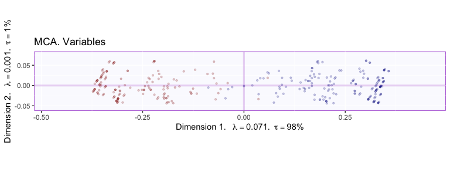

```r
print(aa.5.BaseMapNoLabels.Fi)
```

# 9 Graphs for the sub-analyses

## 9.1 Graph of the Variables for Angers

```r
col4Labels.sub <- col4Labels[varNames != 'City']
axis1 = 1
axis2 = 2
Fj.Angers <- resMCA.Angers$ExPosition.Data$fj
# generate the set of maps
BaseMap.Fj.Angers <- createFactorMap(X = Fj.Angers , # resMCA$ExPosition.Data$fj,
                              axis1 = axis1, axis2 = axis2,
                              constraints = NULL,
                              title = 'Angers. MCA. Variables',
                              col.points = col4Labels.sub,
                              display.points = TRUE,
                              pch = 19, cex = 1,
                              display.labels = TRUE,
                              col.labels = col4Labels.sub,
                              text.cex = 2.5, font.face = "bold",
                              font.family = "sans",
                              col.axes = "darkorchid",
                              alpha.axes = 0.2,
                              width.axes = 1.1,
                              col.background = adjustcolor("lavender",
                                                       alpha.f = 0.2),
                              force = 2, segment.size = 0)
# add labels
labels4MCA.Angers <- createxyLabels.gen(x_axis = axis1,
                                   y_axis = axis2,
               lambda = resMCA.Angers$ExPosition.Data$eigs,
               tau = resMCA.Angers$ExPosition.Data$t)
# make the maps
ca.1.BaseMap.Fj.Angers       <- BaseMap.Fj.Angers$zeMap +  labels4MCA.Angers
ca.2.BaseMapNoDot.Fj.Angers  <- BaseMap.Fj.Angers$zeMap_background +
                          BaseMap.Fj.Angers$zeMap_text + labels4MCA.Angers
```

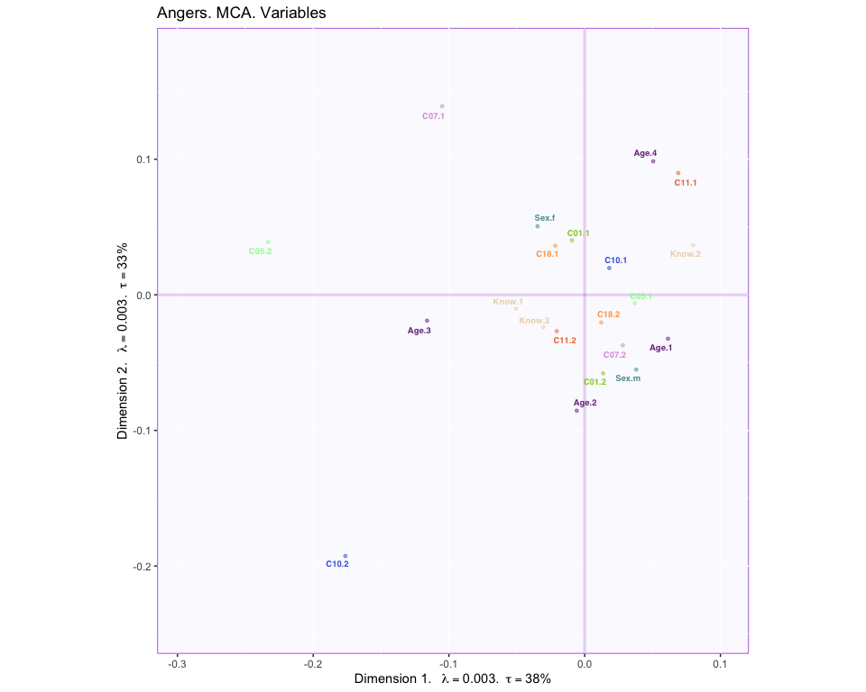

```r
print(ca.1.BaseMap.Fj.Angers)
```

## 9.2 Graph of the Variables for Lille

```r
col4Labels.sub <- col4Labels[varNames != 'City']
axis1 = 1
axis2 = 2
Fj.Lille <- resMCA.Lille$ExPosition.Data$fj
# generate the set of maps
BaseMap.Fj.Lille <- createFactorMap(X = Fj.Lille , # resMCA$ExPosition.Data$fj,
                              axis1 = axis1, axis2 = axis2,
                              constraints = NULL,
                              title = 'Lille. MCA. Variables',
                              col.points = col4Labels.sub,
                              display.points = TRUE,
                              pch = 19, cex = 1,
                              display.labels = TRUE,
                              col.labels = col4Labels.sub,
                              text.cex = 2.5, font.face = "bold",
                              font.family = "sans",
                              col.axes = "darkorchid",
                              alpha.axes = 0.2,
                              width.axes = 1.1,
                              col.background = adjustcolor("lavender",
                                                       alpha.f = 0.2),
                              force = 2, segment.size = 0)
# add labels
labels4MCA.Lille <- createxyLabels.gen(x_axis = axis1,
                                   y_axis = axis2,
               lambda = resMCA.Lille$ExPosition.Data$eigs,
               tau    = resMCA.Lille$ExPosition.Data$t)
# make the maps
cb.1.BaseMap.Fj.Lille       <- BaseMap.Fj.Lille$zeMap + labels4MCA.Lille
cb.2.BaseMapNoDot.Fj.Lille  <- BaseMap.Fj.Lille$zeMap_background +
                          BaseMap.Fj.Lille$zeMap_text + labels4MCA.Lille
```

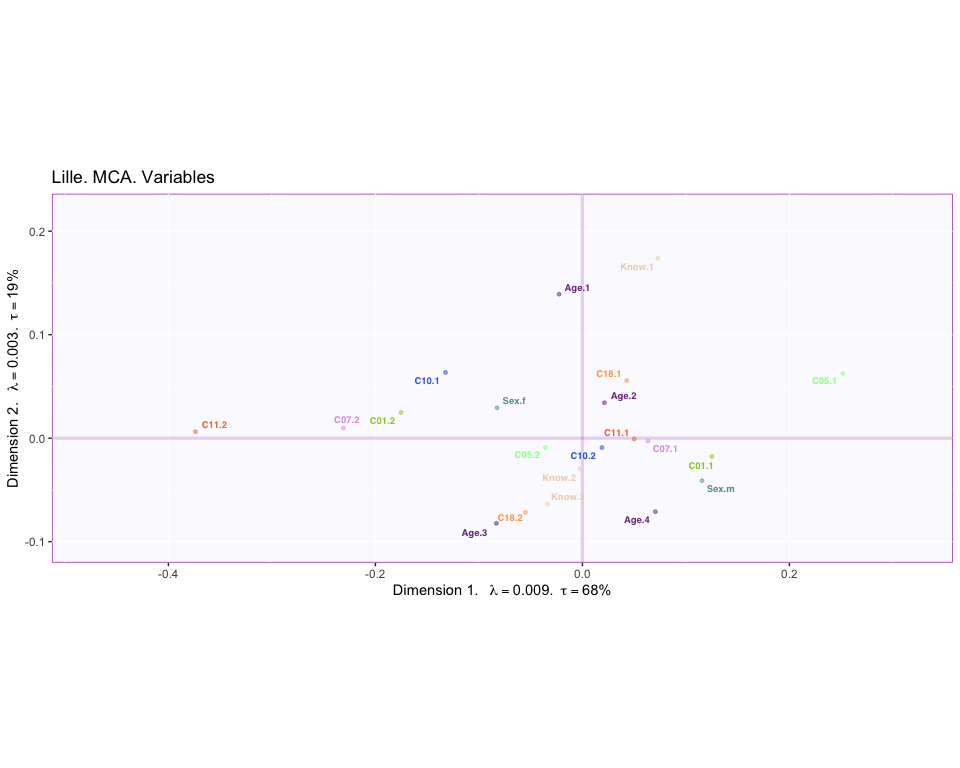

```r
print(cb.1.BaseMap.Fj.Lille)
```

# 10 Save the graphics as a powerpoint

The graphics are saved as a powerpoint called `'cheeseFrom2Cities.pptx'` with the following command

```r
name4Graphs = 'cheeseFrom2Cities.pptx'
list2Graphs <- PTCA4CATA::saveGraph2pptx(file2Save.pptx = name4Graphs,
                 title = 'Attitudes toward Cheese',
                 addGraphNames = TRUE)
```

Note that we could also have created a powerpoint with `Rmarkdown` by using the following options in the preamble:

```r
output:
      powerpoint_presentation:
           slide_level: 4
```

instead of (for example):

```r
output:
       rmarkdown::html_vignette:
          toc: true
          number_sections: true
```